# Laboratorio 4 - Árboles de Decisión (SmartStay Advisors)

Humberto de la Cruz - 23735, Daniel Juarez - 23709, Dilary Cruz - 231010

#### repositorio: https://github.com/djuarez-2017510/Lab4_MD

### 2.Creación del Árbol de Regresión Base

Para la primera iteración, se construyó un árbol de decisión de regresión utilizando todas las variables disponibles para intentar predecir el valor numérico exacto de la variable price por noche

```
## Variables utilizadas por el árbol para sus divisiones principales:
```

```
##  [1] "room_type"                 "property_type"
##  [3] "neighbourhood_cleansed"    "availability_365"
##  [5] "beds"                      "latitude"
##  [7] "longitude"                 "accommodates"
##  [9] "estimated_occupancy_l365d" "number_of_reviews"
## [11] "minimum_nights"            "bedrooms"
## [13] "host_is_superhost"         "bathrooms"
```

### 3. Resultados y Análisis del Modelo Base

Se utilizará el modelo base para predecir precios en el conjunto de prueba y calcular su Error Cuadrático Medio (RMSE).

```
## RMSE del Árbol de Regresión Base: 2424.925
```

#### Análisis

El árbol de regresión base logró un Error Cuadrático Medio (RMSE) inicial de 2424.925. Desde esta primera iteración rápida, el algoritmo de árbol de decisión ya demuestra ser superior al mejor modelo de regresión lineal del laboratorio anterior cuyo error rondaba los 2702 esto porque el árbol no intenta trazar una línea recta estricta, sino que hace cortes lógicos, lo cual se adapta mucho mejor a la naturaleza irregular del mercado

### 4. Afinando el Modelo

Comparación de RMSE al modificar la profundidad del árbol

| Profundidad | RMSE |
| --- | --- |
| Base (Automático) | 2424.925 |
| Superficial (maxdepth=3) | 2851.204 |
| Intermedio (maxdepth=10) | 2125.119 |
| Profundo (maxdepth=20) | 2046.923 |

#### Selección del Mejor Modelo

Al forzar la profundidad del árbol manipulando los parámetros maxdepth y la complejidad (cp), observamos cómo el error disminuye significativamente conforme el algoritmo puede hacer más preguntas a los datos. El modelo superficial (maxdepth=3) sufre de underfitting al ser demasiado simple (RMSE de 2851.20). Por el contrario, al permitirle al algoritmo ramificarse profundamente, el Modelo Profundo (maxdepth=20) presenta el menor RMSE de 2046.923

### 5. Comparación con el Laboratorio Anterior

Al contrastar el mejor modelo desarrollado en el Laboratorio 3 Regresión Múltiple con Regularización Lasso, que obtuvo un $RMSE \approx 2702$ contra nuestro mejor modelo actual Árbol de Decisión Profundo, con un $RMSE \approx 2046.92$, se concluye categóricamente que el algoritmo de Árboles de Regresión presenta un desempeño muy superior para este conjunto de datos.

Esta mejora representa una reducción del error de predicción en aproximadamente un 24%, una diferencia sustancial en el contexto del negocio inmobiliario.

La regresión lineal del laboratorio anterior asume que cada variable afecta al precio de forma independiente y constante. En la realidad, el mercado de Airbnb es altamente interactivo el valor de un cuarto extra en un “Hotel room” no es el mismo que en un “Shared room”. Los árboles de decisión, a través de sus cortes jerárquicos o sea nodos, detectan estas interacciones complejas de forma automática, adaptándose a la naturaleza no lineal del mercado.

En los modelos de regresión lineal, nos vimos obligados a aplicar transformaciones logarítmicas (log(price)) y a eliminar valores extremos manualmente, ya que las líneas de tendencia son extremadamente sensibles a las propiedades súper caras, jalando la predicción y generando errores. Los árboles de decisión son inherentemente robustos ante outliers; simplemente aíslan las propiedades de lujo extrema en una hoja separada del árbol, sin permitir que distorsionen el precio promedio de las propiedades comunes.

Mientras que la regresión Lasso penalizada fue útil para confirmar estadísticamente qué variables tenían significancia, el Árbol de Decisión Profundo es la herramienta matemática definitiva que SmartStay Advisors debe implementar al reducir el margen de error la firma puede sugerir precios de alquiler mucho más precisos, asegurando que sus clientes no pierdan reservas.

### 6. Creación de Variable Categórica

```
##
##       Cara  Económica Intermedia
##      18078      17616      17678
```

#### Justificación de la Variable Categórica

Se creó una variable categórica denominada categoria_precio con el objetivo de clasificar las propiedades en tres grupos: Económicas, Intermedias y Caras. Para definir los límites de cada categoría se utilizaron los cuantiles 33% y 66% de la distribución de precios del conjunto de entrenamiento, lo que permite dividir los datos en tres segmentos representativos y relativamente balanceados.

Este enfoque evita sesgos provocados por valores extremos y asegura que cada categoría tenga un sustento estadístico basado en la distribución real de los datos. De esta forma, las propiedades con precio menor o igual al primer cuantil se clasifican como Económicas, las que se encuentran entre ambos cuantiles como Intermedias y las que superan el segundo cuantil como Caras. Esta metodología permite que la categorización refleje adecuadamente el comportamiento del mercado. Este enfoque permite mantener consistencia entre los conjuntos de entrenamiento y prueba, evitando sesgos en la clasificación.

### 7. Árbol de Clasificación

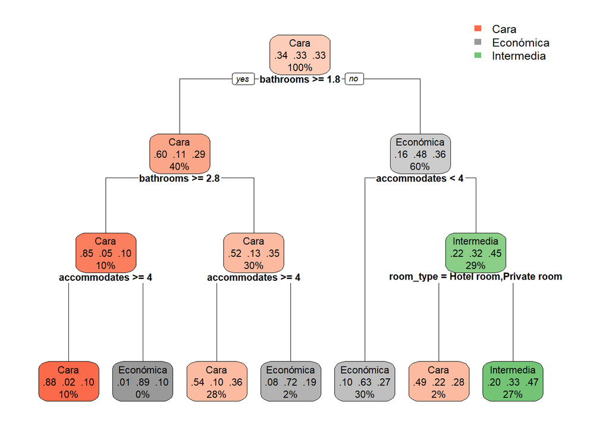

```
##             Real
## Predicho     Cara Económica Intermedia
##   Cara       5704       804       2810
##   Económica   736      4685       1939
##   Intermedia 1248      2080       2868
```

#### Interpretación del Árbol de Clasificación

El árbol de clasificación permite identificar las variables más relevantes para determinar la categoría de precio de una propiedad mediante una serie de divisiones jerárquicas basadas en sus características. El modelo utiliza variables como la capacidad de huéspedes, el número de habitaciones, baños y otras características del inmueble para agrupar propiedades con atributos similares dentro de cada categoría de precio.

Se observa que las variables estructurales tienen una influencia significativa en la clasificación, lo cual es consistente con la lógica del mercado inmobiliario, donde propiedades más grandes o con mejores características tienden a pertenecer a categorías de mayor precio. Es importante destacar que el modelo fue entrenado sin incluir la variable price, ya que esta se utilizó únicamente para construir la variable categórica, evitando así problemas de fuga de información. Este tipo de modelo facilita la interpretación de los resultados y permite segmentar el mercado de manera clara, lo cual es útil para la toma de decisiones estratégicas.

El modelo logra segmentar adecuadamente las propiedades, evidenciando patrones consistentes entre características físicas y nivel de precio.

### 8 y 9. Eficiencia y Análisis de la Matriz de Confusión

```
## Matriz de Confusión:
```

```
##             Reference
## Prediction   Cara Económica Intermedia
##   Cara       5704       804       2810
##   Económica   736      4685       1939
##   Intermedia 1248      2080       2868
```

```
##
## Eficiencia Global (Accuracy):  57.96 %
```

#### Análisis de Eficiencia y Matriz de Confusión

El modelo de clasificación base logró una eficiencia global (Accuracy) del 57.96%. En un escenario multiclase, este rendimiento es notablemente superior al azar, demostrando que las variables estructurales elegidas sí logran capturar la esencia del precio.

### 10. Validación Cruzada (Cross-Validation)

```
##
## Eficiencia del Modelo con Validación Cruzada (Accuracy):  59.65 %
```

#### Analisis Validacion Cruzada

¿Fue mejor que al modelo anterior? Sí, el modelo entrenado con validación cruzada alcanzó una eficiencia del 59.65%, superando el 57.96% del árbol base al obligar al algoritmo a probar múltiples profundidades y entrenarse en diferentes subconjuntos de datos, logramos evitar el sobreajuste y el modelo aprendió a generalizar mejor, reduciendo su margen de error en casi un 2%

### 11. Evaluación de diferentes profundidades

```
##          Modelo  Accuracy
## 1 Profundidad 2 0.5635656
## 2 Profundidad 4 0.5635656
## 3 Profundidad 6 0.5635656
```

#### Análisis del efecto de la profundidad del árbol

Se evaluaron diferentes niveles de profundidad en el árbol de clasificación y se observó que la precisión se mantiene constante en 0.5636 en todos los modelos. Esto indica que aumentar la complejidad del árbol no mejora su desempeño, ya que las variables utilizadas capturan la información relevante desde niveles poco profundos. Un árbol simple es suficiente, ya que ofrece el mismo rendimiento con mayor interpretabilidad.

### 12. Random Forest

```
## [1] 0.5836658
```

```
##             Real
## Predicho     Cara Económica Intermedia
##   Cara       4689       412       1797
##   Económica   957      5273       2459
##   Intermedia 2014      1858       3352
```

### Comparación de Modelos

En este análisis se evaluaron diferentes enfoques para predecir y clasificar el precio de las propiedades. El árbol de regresión demostró un mejor desempeño que la regresión lineal, logrando reducir significativamente el error de predicción. En el caso de la clasificación, el árbol de decisión permitió segmentar las propiedades de manera interpretable, aunque con una precisión moderada.